# Tipos de probabilidad

Debido a que la probabilidad es la cuantificación de la incertidumbre y la incertidumbre es en si misma es la toma de decisiones con información incompleta, a menudo cuando tomas decisiones en una situación con información incompleta puede suceder que te llegue información nueva que genere cambio en las probabilidades, y ese tipo de situaciones tiene que cuantificarse con otros conceptos adicionales sobre el concepto de probabilidad básico.

Así de esta manera tenemos 3 tipos a definir:

- Probabilidad conjunta
- Marginal
- Condicional

Lo explicaremos a traves de un ejemplo de dados.

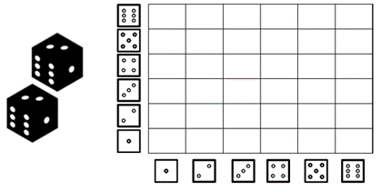

Vamos a jugar con 2 dados y muestrear y obtener el espacio muestral de los 2 dados. Este espacio se ve en la imagen anterior con filas y columnas. Así tenemos 36 posibles combinaciones con los resultados.

Preguntas:

- ¿Cual es la probabilidad de que ambos dados caigan en numero par? $P(par,par)=\frac 9 {36}=\frac 1 {4}$  
  Haciendo el conteo anterior, tenemos el siguiente espacio muestral, como vemos son 3 columnas por 3 filas

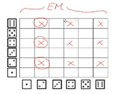

- ¿Cuál es la probabilidad de que un dado A caiga en par sabiendo que el otro dado B es par? Esta pregunta es ligeramente diferente a la anterior,es decir supone una condición previa al espacio muestral que va ser la siguiente. Nosotros considerando nuestro espacio original de abajo, tenemos que considerar ahora solo las situaciones en las que ya sabemos que B es par. B es par en las siguientes:

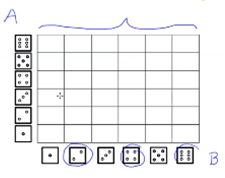

De esta manera ya sabemos que los estados posibles ahora no son 36, sino que están acotados bajo la condición previa, entonces serían solo 18 posibilidades. Es decir la condición que pusimos, lo que hizo fue reducir el espacio muestral.

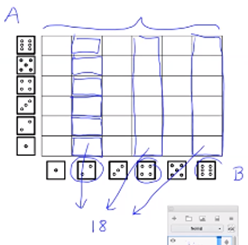

Así nosotros decimos ¿Cual es la probabilidad de que A sea par dado que B ya es par? $P(A=\text{par }|B= \text{par})=$. La barra $|$ denota una **probabilidad condicional**. Habiendo ya restringido el espacio muestral, lo que se procede a hacer es un conteo del espacio, dando un resultado como lo siguiente:

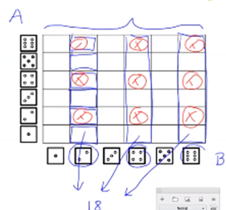

Como se puede observar, el numero de casos exitosos no cambio, lo que cambio fue el numero de eventos posibles o el espacio muestral, eso modifica la expresión. $P(A|B)=\frac 9 {18}$, así que son 2 probabilidades distintas.

¿cómo están relacionadas? por que esto tiene una relación.  
Resulta que para explicarlo me hago la pregunta ¿cuál es la probabilidad de que el dado B caiga en par? $P(B=\text{par})$, es decir no impone una condición, entonces aquí yo puedo usar todo el espacio muestral completo, y buscar cuando B sea par en mi espacio muestral, y procedo a hacer un conteo.

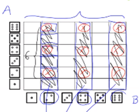

Entonces tengo 18 espacios en los que B es par, lo que quiere decir que $P(B=\text{par})=\frac{18}{36}$

¿cuál es la relación? Bueno son 3 probabilidades que corresponden a 3 preguntas diferentes, pero resulta si tomamos las 2 probabilidades $P(A|B)=\frac 9{18}$ y $P(B=\text{par}=\frac{18}{36})$ y las multiplico , obtenemos $P(A|B)\cdot P(B)=\frac 9{18}\cdot \frac{18}{36}=\frac 1{4}$ que es la probabilidad conjunta $P(par,par)=\frac 1{4}$. Entonces podemos decir que la probabilidad conjunta de que suceda A y B es igual a la probabilidad condicional que sucede A dado que yo se que sucedió B, por la probabilidad de que sucedió B. Esto es una regla general que se llama la regla del producto: $$P(A,B)=P(A|B)\cdot P(B)$$

Esta es una regla general que se utiliza para descomponer probabilidades condicionales. Entonces esta es la expresión general para las probabilidades condicionales (Regla del producto).

### Probabilidad marginal

¿A qué corresponde una probabilidad marginal? Marginal es cuando tu obtienes una propiedad sencilla a partir de una probabilidad conjunta $p(A)\rightarrow p(A,B)$ es decir; yo tengo mis probabilidades conjuntas de dos sucesos $P(A,B)$ y tu quieres preguntarte solo por la probabilidad de que suceda el primer suceso independiente de lo que pase con el otro, así eso se define como: $$p(A)=\sum_b {p(\overline A ,B)}$$

Si lo incluyo en la regla del producto me daría un proceso cíclico de definir la Probabilidad marginal en función de la probabilidad conjunta y viceversa, es común verlo en libros de probabilidad

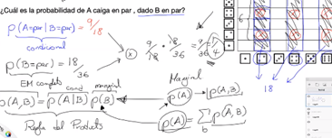

## Resumen

### Probabilidad conjunta

$$P(A,B)=P(A\&B)=P(A\cap B)$$ Que es una probabilidad que considera de diferentes pero simultáneos eventos aleatorios, y está se relaciona con la **probabilidad condicional**

### Probabilidad condicional

$$P(A\text{dado }B)=P(A|B)$$ Se relaciona con la probabilidad conjunta por medio de la regla del producto. $$P(A\cap B)=P(A|B)P(B)$$

- NOTA: Es importante aclarar que la probabilidad condicional no implica causalidad por medio de la regla del producto; es decir probabilidad de que suceda A dado que sucedió B. No quiere decir que B va a ser la causa de A, puede que en algunas situaciones suceda, pero son en principio 2 conceptos diferentes. Y POR ELLO EN PROBABILIDAD SE DICE QUE LAS PROBABILIDADES CONDICIONALES NO REFLEJAN CONDICIONES DE CAUSALIDAD.

### Probabilidad marginal

Concluimos diciendo que la probabilidad marginal se obtienen haciendo sumas sobre ciertas variables aleatorias o ciertas ocurrencias de ciertas variables aleatorias dentro de la probabilidad conjunta. Siempre que hagamos sumas de probabilidades conjuntas y deje libre una de las variables entonces decimos que estamos obteniendo la probabilidad marginal de esa variable que está libre o de ese evento aleatorio.